# Analytic Plan

Extreme heat, PM2.5, and congenital heart defects

Will Simmons

12 March 2020

#### **Summary**

This document describes our 2020 research on the joint associations between maternal exposure to extreme heat, ambient PM2.5 levels, and offspring CHD risk. It contains a general timeline up to the submission of my master’s thesis and a brief analytic plan.

##### *Updated Timeline:*

- 2/17 Introduction draft (COMPLETE)
- 2/19 DAG + Descriptives (DRAFT COMPLETE)
- 2/21 Initial model discussions (COMPLETE)
- 2/28 Analytic plan draft (COMPLETE - this document)
- (March) Conversation with NBDPS team (ongoing)
- 3/20 Methods draft
- 3/20 Send Intro + Methods drafts to Jeanette
- 3/31 Draft analyses complete
- 4/05 Results draft to Jeanette
- 4/10 Discussion and Conclusion drafts to Jeanette
- 4/12 Abstract draft to Jeanette
- 4/12 References
- 4/14 Internal Draft to myself
- 4/19 Draft to Jeanette
- 4/28 Complete Thesis to admin

#### Does maternal exposure to extreme heat events modify the association between PM2.5 exposure and congenital heart defects (CHDs) in offspring?

Approaches to operationalizing EHEs:

- Priority:
  - Number of heat-days above a certain heat threshold (90th or 95th pecentile) during critical window
- If needed after exploratory analysis:
  - Number of EHEs (3 days above 90th percentile, 2 days above 95th percentile)
  - Longest single EHE

#### **Brief analytic plan**

##### *Study Aims*

1. Assess whether the association between maternal PM2.5 exposure during weeks 3-8 of pregnancy and offspring CHD risk (odds) differs across levels of extreme heat exposure. Note: See Table 1 for CHD outcome distribution and Figure 1 for PM2.5 exposure distribution.
   1. Investigate nonlinear associations among exposure, modifier, and outcome.
2. Explore both additive and multiplicative interaction and the implications of each.
3. If appropriate after analysis of the cumulative heat-days measure above, explore other definitions of extreme heat exposure and their implications for this potential interaction. Note: See Figure 2 for distribution plots for each of these definitions.
   1. Frequency of extreme heat events, defined as a certain number of contiguous days above a threshold
   2. Duration of the longest single EHE
   3. Other definitions

##### *Hypotheses*

1. Primary: The association between maternal PM2.5 exposure and offspring CHD risk (odds) will be **more positive** with increasing levels of extreme heat exposure.
2. Secondary: Cumulative exposure to days above a certain temperature threshold will be the most significant heat-related modifying factor (see Lin et al, 2018), potentially signifying the importance of longer-term extreme heat exposure during critical pregnancy windows.

##### *Methods*

Variables of interest:

- Exposures: maternal exposure to PM2.5 weeks 3-8 of pregnancy, measured continuously (μg/m^3) or categorically
- Modifiers: maternal exposure to extreme heat weeks 3-8 of pregnancy, as defined above (priority: cumulative exposure; other potential measures include frequency of EHEs, duration of longest EHE)
- Outcomes: offspring CHD (LVOTO, RVOTO excl. Ebstein’s anomaly, septal defects, conotruncal defects, VSDpm, ASD-II), either individually or aggregated into presence/absence of any of the above CHDs

Statistical methods:

- Consider nonlinear relationships (e.g. using piecewise functions, splines) to parameterize associations between exposure, modifier, and outcome
- Fit adjusted multivariable logistic regression equation for each CHD outcome and assess additive/multiplicative interaction
- Calculating additive interaction
  - If both PM2.5 and heat measure are operationalized categorically, RERI calculated in traditional way (e.g. Stingone et al, 2019)
  - If either is operationalized continuously, can use method described in Knol et al, 2007 (IJE)
  - In either case, with additive interaction, be careful of presenting in adjusted case control context (see Skrondal et al 2003, AJE; VanderWeele and Vansteelandt 2001, AJE)

#### **Figures**

##### Table 1: Distribution of Congenital Heart Defects in Sample

| Defect | N |
| --- | --- |
| VSDpm | 407 |
| ASD-II | 420 |
| RVOTO (excl. Ebstein) | 447 |
| LVOTO | 588 |
| Conotruncal | 639 |
| Septal | 958 |

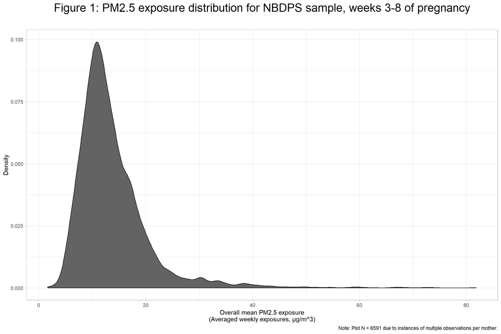

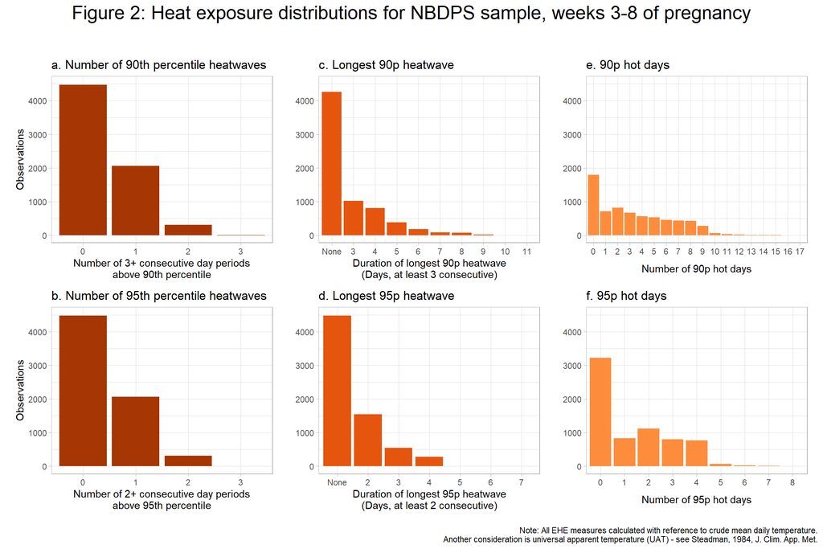